# TD 4 — Explorer le modèle de production de Schaefer

Introduction à l’halieutique — M2 Sciences de la Mer

Auteur·rice

Laurent Dubroca

Date de publication

23 novembre 2026

# Objectifs et consignes

Ce TD accompagne le cours « Le modèle de production de Schaefer ». Vous allez **programmer le modèle**, puis **explorer l’effet de ses paramètres** pour comprendre la dynamique d’une population exploitée :

1. calculer une année de dynamique à la main, puis avec une fonction ;
2. simuler une trajectoire sur plusieurs dizaines d’années ;
3. explorer l’effet du taux intrinsèque d’accroissement $r$ et de la capacité de charge $K$ ;
4. tester l’effet de captures constantes et retrouver le rendement maximal durable.

**Durée** : environ 1 h 15.

**Rendu** : ce document complété (`.qmd` **et** `.html`), à envoyer par mail à l’intervenant à la fin de la demi-journée. Il est noté. Commentez vos résultats à la place de *(commentez ici)*.

Cherchez par vous-même : la correction sera fournie après la séance.

```r
if (!requireNamespace("ggplot2", quietly = TRUE)) install.packages("ggplot2")
library(ggplot2)
```

# 1 Rappels : le modèle et ses termes

Le modèle de Schaefer décrit l’évolution de la **biomasse totale** d’un stock, sans distinguer les âges. Sa forme annuelle (temps discret) s’écrit :

$$B_{t+1} = B_t + \underbrace{r\,B_t\left(1 - \frac{B_t}{K}\right)}_{\text{production biologique}} - C_t$$

Les termes du modèle

| Terme | Signification | Unité |
| --- | --- | --- |
| $t$ | année |  |
| $B_t$ | **biomasse** du stock l’année $t$ | t |
| $B_0$ | biomasse initiale (au début de la simulation) | t |
| $r$ | **taux intrinsèque d’accroissement** : productivité maximale du stock, quand il est très peu abondant | an<sup>-1</sup> |
| $K$ | **capacité de charge** : biomasse d’équilibre du stock non exploité (biomasse vierge $B_0$) | t |
| $C_t$ | **captures** de l’année $t$ | t |
| $r\,B_t(1 - B_t/K)$ | **production biologique** (ou production excédentaire) de l’année | t |

Le facteur $(1 - B_t/K)$ traduit la **densité-dépendance** : plus le stock est abondant, plus la compétition freine sa croissance. Sans pêche, la biomasse tend vers $K$. La production est maximale pour $B = K/2$, où elle vaut $rK/4$ : c’est le **rendement maximal durable** (MSY), et $B_{MSY} = K/2$.

# 2 Une année de dynamique

## 2.1 À la main

Prenons $B_t = 10$ t, $r = 0{,}2$, $K = 100$ t et $C_t = 1$ t.

```r
10 + 0.2 * 10 * (1 - 10 / 100) - 1
```

```
[1] 10.8
```

La production de l’année vaut $0{,}2 \times 10 \times 0{,}9 = 1{,}8$ t ; on en prélève 1 t, le stock gagne donc 0,8 t.

### 2.1.1 À vous

1. Recalculez $B_{t+1}$ avec $r = 0{,}5$ (les autres valeurs inchangées). Puis avec $r = 0{,}5$ et $K = 10$. Expliquez le dernier résultat.
2. Avec $r = 0{,}2$, $K = 100$ et une capture de **5 t par an**, calculez la biomasse sur trois années successives à partir de $B_0 = 10$ t. Que se passe-t-il ?

```r
# votre code ici
```

*(commentez ici)*

## 2.2 Une fonction pour une année

Pour ne pas réécrire la formule, on l’enferme dans une **fonction**.

### 2.2.1 À vous

Écrivez une fonction `biomasse_suivante(B, r, K, C)` qui renvoie $B_{t+1}$, et vérifiez qu’elle donne 10,8 pour l’exemple ci-dessus. Pour éviter une biomasse négative, renvoyez `max(..., 0)`.

```r
# votre code ici
```

# 3 Simuler une trajectoire

En appliquant la fonction année après année, on obtient une trajectoire. La fonction `simuler()` ci-dessous le fait pour vous : elle renvoie un tableau avec les années, la biomasse et les valeurs de $r$, $K$ et $C$ utilisées. Pour comparer plusieurs scénarios, on les simule un par un, puis on **empile** les tableaux avec `rbind()` pour les tracer ensemble.

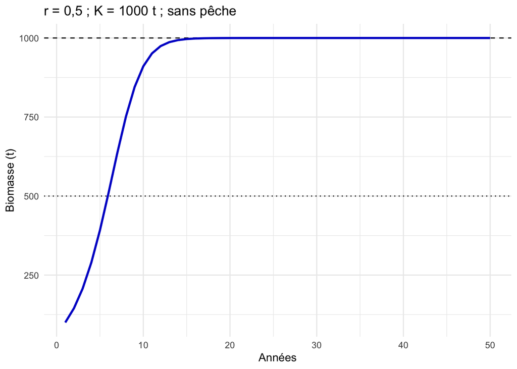

```r
# Si vous n'avez pas encore écrit biomasse_suivante(), la voici :
biomasse_suivante <- function(B, r, K, C = 0) {
  max(B + r * B * (1 - B / K) - C, 0)
}
simuler <- function(B0, r, K, C = 0, n = 50) {
  B <- numeric(n)
  B[1] <- B0
  for (t in 1:(n - 1)) {
    B[t + 1] <- biomasse_suivante(B[t], r, K, C)
  }
  data.frame(annee = 1:n, B = B, r = r, K = K, C = C)
}

traj <- simuler(B0 = 100, r = 0.5, K = 1000)
ggplot(traj, aes(annee, B)) +
  geom_hline(yintercept = c(500, 1000), linetype = c("dotted", "dashed")) +
  geom_line(colour = "blue3", linewidth = 1) +
  labs(x = "Années", y = "Biomasse (t)", title = "r = 0,5 ; K = 1000 t ; sans pêche") +
  theme_minimal()
```

Partie de 100 t, la biomasse croît d’abord vite, puis ralentit et se stabilise à $K$ : c’est la courbe **logistique**, en forme de S.

Exemple de comparaison de deux scénarios :

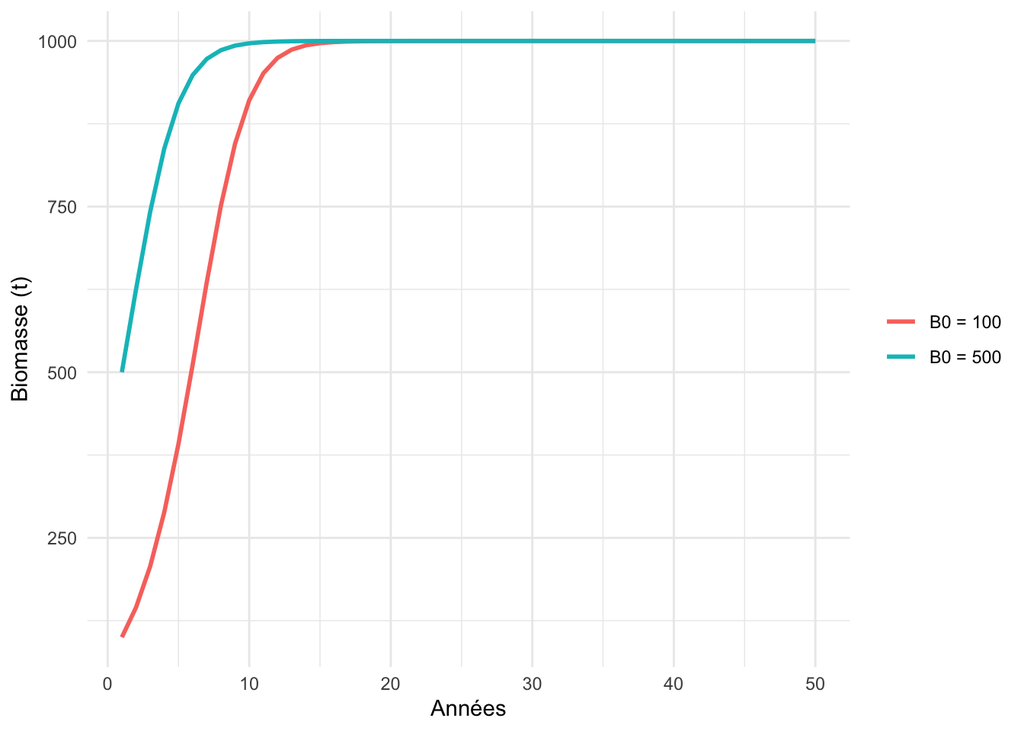

```r
s1 <- simuler(B0 = 100, r = 0.5, K = 1000)
s2 <- simuler(B0 = 500, r = 0.5, K = 1000)
deux <- rbind(s1, s2)           # empile les deux tableaux
deux$depart <- factor(rep(c("B0 = 100", "B0 = 500"), each = 50))
ggplot(deux, aes(annee, B, colour = depart)) +
  geom_line(linewidth = 1) +
  labs(x = "Années", y = "Biomasse (t)", colour = NULL) +
  theme_minimal()
```

Pour distinguer des scénarios qui diffèrent par $r$, $K$ ou $C$, il suffit d’utiliser ces colonnes pour la couleur, par exemple `aes(colour = factor(r))`.

## 3.1 La production en fonction de la biomasse

### 3.1.1 À vous

1. Tracez la production $r\,B(1 - B/K)$ pour $B$ allant de 0 à $K$, avec $r = 0{,}5$ et $K = 1000$.
2. Pour quelle biomasse est-elle maximale, et que vaut ce maximum ? Comparez avec $K/2$ et $rK/4$.
3. Superposez la courbe pour $r = 1$ : qu’est-ce qui change, qu’est-ce qui ne change pas ?

```r
# votre code ici
```

*(commentez ici)*

# 4 Explorer l’effet de r et K

## 4.1 Effet du taux intrinsèque d’accroissement r

### 4.1.1 À vous

1. Sans pêche, à partir de $B_0 = 100$ t et avec $K = 1000$ t, simulez la trajectoire pour $r$ = 0,2 ; 0,5 ; 1 et 1,8. Représentez-les sur un même graphique.
2. Combien d’années faut-il pour atteindre 95 % de $K$ dans chaque cas ? Quelles espèces pourraient correspondre à un $r$ faible ou élevé ?

```r
# votre code ici
```

*(commentez ici)*

## 4.2 Quand r devient très grand : oscillations et chaos

### 4.2.1 À vous

1. Simulez 100 ans sans pêche ($B_0 = 100$, $K = 1000$) pour $r$ = 2,2 ; 2,5 et 2,9. Que se passe-t-il ?
2. Pour chaque valeur, comptez le nombre de valeurs **distinctes** prises par la biomasse pendant les 50 dernières années (`length(unique(round(...)))`).

```r
# votre code ici
```

*(commentez ici)*

## 4.3 Effet de la capacité de charge K

### 4.3.1 À vous

Simulez la trajectoire sans pêche avec $r = 0{,}5$, $B_0 = 50$ t et $K$ = 500, 1000 et 2000 t. Tracez ensuite $B/K$ au lieu de $B$. Que constatez-vous ?

```r
# votre code ici
```

*(commentez ici)*

# 5 Ajouter la pêche : captures constantes

On fixe maintenant $r = 0{,}4$ et $K = 1000$ t, donc $MSY = rK/4 = 100$ t par an et $B_{MSY} = 500$ t. Le stock part de l’état vierge ($B_0 = K$) et subit chaque année la même capture $C$.

## 5.1 À vous

1. Simulez 100 ans avec $C$ = 80, 100 et 110 t. Que devient le stock ?
2. Sur 300 ans, testez les captures $C$ = 99, 100 et 101 t : regardez la biomasse de la dernière année avec `tail(..., 1)`. Quelle est la plus grande capture constante soutenable ? Comparez-la au MSY.
3. Avec $C = 80$ t, partez maintenant de $B_0 = 300$ t, puis de $B_0 = 250$ t. Comment l’expliquer ? (Indice : cherchez les biomasses où la production est égale à 80.)

```r
# votre code ici
```

*(commentez ici)*

# 6 Synthèse

En quelques phrases, répondez :

1. Quel est le rôle de $r$ ? Celui de $K$ ?
2. Pourquoi un stock pêché peut-il être plus productif qu’un stock vierge ?
3. Pourquoi est-il dangereux de fixer une capture constante proche du MSY ?

*(rédigez ici)*

**NotePour aller plus loin**

Le package **MQMF** (Haddon 2020), utilisé dans les TD suivants, propose la fonction `discretelogistic()`, qui fait la même simulation que `simuler()`. Vous pouvez comparer : `MQMF::discretelogistic(r = 0.5, K = 1000, N0 = 100, Ct = 0, Yrs = 50)`.